# FP_Coint_Backtest_DEMO

[figure not shown]

## Pairs Trading with Reversion Evaluation

### Dr Richard Diamond

**PLEASE NOTE CERTAIN CODE NOT RELEASED**

## Resources for TS Topic

- Project Brief (TS Topic)
- Project Workshop (TS Topic)
- Cointegration Lecture
- Cointegrartion Case B and R code (10Y vs 25Y spot rates)
- Pairs Trading Python Lab (this session)
- Additional Material - curated readings 1) E. Zivot chapter, 2) P. McSharry example, 3) R. Diamond WILMOTT paper

While developing the strategy we rely on the frameworks of Vector Autoregression (multivariate linear regression) and Cointegration Analysis (Vector Error Correction Model).

Supporting numerical techniques -- which is what you will implement/compute as well:

- AIC/BIC for optimal lag selection, optionally
- Dickey-Fuller Test for stationarity ("unit root")
- Engle-Granger to confirm cointegration between a pair
- OU process for evaluating the quality of mean-reversion

```python
%%html
<style> .container { width: 100%} </style>
```

```python
%pylab inline

import warnings
import numpy as np
import pandas as pd
import datetime as dt

#The package now includes various advances, such as Value at Risk, Vector Autoregression, Vector Error Correction
import statsmodels.tsa.api as sm #or as ts.

from scipy import optimize
from IPython.display import Image
```

## Foreword on Backtesting with Quantopian

How do we know that a strategy/portfolio/single stock beats the market? Below is a simple backtest example on the directional 100% investment in Marriott International stock.

Start 2013-01-02, end 2018-06-25.

```
cmd
pip install pyfolio
```

**CAUTION** Pyfolio package likely require OLD VERSIONS of matplotlib and numpy (possibly entire pre Python 3.7 core) to run correct.

If things not working for you, turn to Quantopian IDE ([website](https://www.quantopian.com/algorithms)) for full backtesting capabilities and examples. You will need to register.

| Start date End date Total months | 2013-01-02 2018-06-25 65 Backtest | 2013-01-02 2018-06-25 65 |
| --- | --- | --- |
| Annual return | 26.2% |  |
| Cumulative returns | 258.3% |  |
| Annual volatility | 21.3% |  |
| Sharpe ratio | 1.20 |  |
| Calmar ratio | 0.86 |  |
| Stability | 0.86 |  |
| Max drawdown | -30.5% |  |
| Omega ratio | 1.23 |  |
| Sortino ratio | 1.76 |  |
| Skew | NaN |  |
| Kurtosis | NaN |  |
| Tail ratio | 1.09 |  |
| Daily value at risk | -2.6% |  |

| Worst drawdown periods | Net drawdown in % | Peak date | Valley date | Recovery date | Duration |
| --- | --- | --- | --- | --- | --- |
| 0 | 30.49 | 2015-03-02 | 2016-01-19 | 2016-12-07 | 463 |
| 1 | 14.82 | 2014-09-18 | 2014-10-13 | 2014-10-29 | 30 |
| 2 | 12.31 | 2018-01-29 | 2018-06-25 | NaT | NaN |
| 3 | 11.62 | 2013-05-15 | 2013-06-24 | 2013-09-18 | 91 |
| 4 | 11.10 | 2017-06-02 | 2017-08-17 | 2017-09-28 | 85 |

| Stress Events | mean | min | max |
| --- | --- | --- | --- |
| Apr14 | 0.21% | -2.38% | 2.31% |
| Oct14 | 0.37% | -2.90% | 3.54% |
| Fall2015 | -0.13% | -3.81% | 5.05% |
| New Normal | 0.10% | -7.31% | 6.36% |

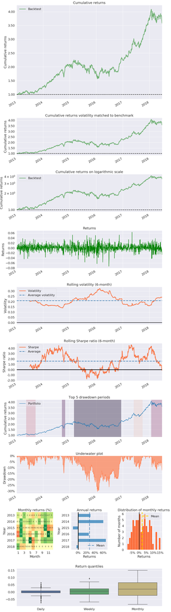

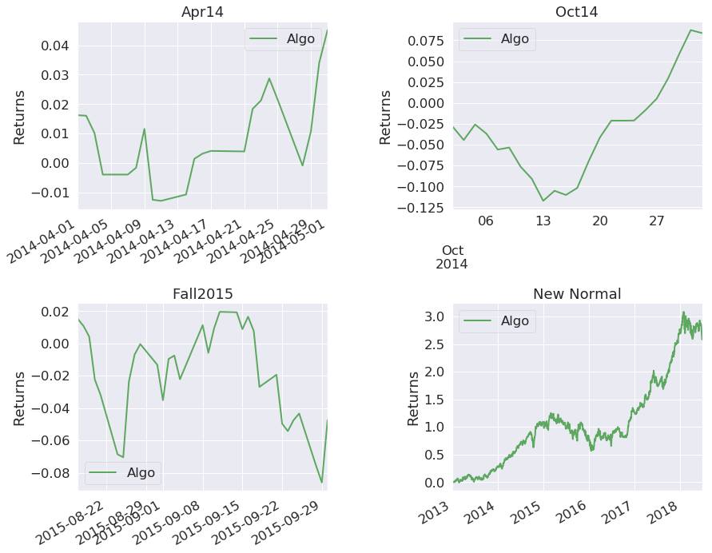

```python
import pyfolio as pf

tickers_hotel = [['MAR', 'Marriott International'], ['IHG', 'InterContinental Hotels']]

cointprices = pd.read_excel('data_coint/prices_coint_hotel.xlsx', index_col=0)
cointprices.columns = [tickers_hotel[0][0],tickers_hotel[1][0]]

returns = cointprices['MAR'].pct_change()


pf.create_full_tear_sheet(returns)
```

# Vector Auto Regression

This is a model-free set up in which we regress ''everything on everything". The system is endogenous.

Asset returns are are made dependent on their own lagged values (past values).

You might also heard about dynamic structural equations modelling (DSEM). Well, Vector Autoregression is case of DSEM when there are no latent variables (all variables observable) and we rely on residuals. $p$ is the number of lagged values as determined by AIC, BIC tests.

\begin{eqnarray*} y_t &=& B_{\text{Constant}} + y_{t-1}B_1 + \cdots + y_{t-p}B_p +\varepsilon_t, \end{eqnarray*}

The following function *VAR(data, p)* estimates using Vector Autoregression in matrix form, calling on general multivariate linear regression model.

The function also checks stability of the system: whether all roots of the characteristic polynomials $\det(\lambda I - \widehat{B}_j)$ are within the unit circle for all $j = 1, \ldots, p$. If not, a warning will be issued.

The result is the estimated block matrix:

\begin{equation*} \widehat{B} = \left[ \begin{array}{l} \widehat{B}_{\text{Constant}} \\ \widehat{B}_1 \\ \vdots \\ \widehat{B}_p \\ \end{array} \right]. \end{equation*}

## Multivariate Linear Regression

Consider a multivariate linear regression model in which we have $i=1, \ldots, m$ observations $y_i = (y_{i1}, \ldots, y_{in})^T$ that we are regressing on $x_i = (x_{i1}, \ldots, x_{i\ell})^T$:

\begin{equation*} \left[ \begin{array}{ccc} y_{11} & \cdots & y_{1n} \\ \vdots & & \vdots \\ y_{m1} & \cdots & y_{mn} \\ \end{array} \right] = \left[ \begin{array}{ccc} x_{11} & \cdots & x_{1\ell} \\ \vdots & & \vdots \\ x_{m1} & \cdots & x_{m\ell} \\ \end{array} \right] \left[ \begin{array}{ccc} \beta_{11} & \cdots & \beta_{1n} \\ \vdots & & \vdots \\ \beta_{\ell1} & \cdots & \beta_{\ell n} \\ \end{array} \right] + \left[ \begin{array}{ccc} \varepsilon_{11} & \cdots & \varepsilon_{1n} \\ \vdots & & \vdots \\ \varepsilon_{m1} & \cdots & \varepsilon_{mn} \\ \end{array} \right] \end{equation*}

This forms the basis for both, Vector Autoregression and Augmented Dickey-Fuller (ADF) Test. The model may also be written in short form as:

\begin{equation*} y_t = x_tB+\varepsilon_t, \end{equation*}

where $\varepsilon_t = (\varepsilon_{t1}, \ldots, \varepsilon_{tn})^T$ and we have substituted $t$ for $i$. In matrix notation the model may actually be written even shorter as:

\begin{equation*} Y = XB+\varepsilon \end{equation*}

linear_regression_core() computes regression coefficients (estimates the model), given pre-formed matricies.

\begin{equation*} \begin{array}{lcrcl} \text{Number of observations:} & \qquad & m & & \\ \text{Number of regressands:} & \qquad & n & & \\ \text{Number of regressors:} & \qquad & \ell & & \\ \text{Estimate of $B$:} & \qquad & \widehat{B} & = & (X^TX)^{-1}X^TY \\ \text{Residuals:} & \qquad & \widehat{\varepsilon}&= &Y-X\widehat{B} \\ \end{array} \end{equation*}

The following output is useful for **inference**: decisions on specification of regression model and significance of coeffiecients hypothesis testing (if the true value of coeffient is zero, we infer that corresponding variable does not have explanatory power).

\begin{equation*} \begin{array}{lcrcl} \text{Residual covariance matrix:} & \qquad & \widehat{\Sigma} &=& \widehat{\varepsilon}^T \widehat{\varepsilon} \big/ m\\ \text{Covariance matrix of regression coefficients:} & \qquad & \widehat{CoV} &=& \widehat{\Sigma}\otimes (X^TX)^{-1} \\ \text{Standard error of regression coefficient:} & \qquad & \left(\text{Var}\left(\widehat{\beta}_{kj}\right)\right)^{1/2}&=& \left(\frac{m}{m-\ell}\text{diag}(\widehat{CoV})_{kj}\right)^{1/2} \\ \text{t-test statistic for whether regression coefficient is zero:} & \qquad & \text{tstat}_{kj} &=& \widehat{\beta}_{kj}\big/\left(\text{Var}\left(\widehat{\beta}_{kj}\right)\right)^{1/2} \\ \text{$p$-value for the corresponding t-test statistic:} & \qquad & \text{pvalue}_{kj}&\\ \text{Akaike information criterion:} & \qquad & AIC & = & \log\left|\widehat{\Sigma}\right|+2\ell n\big/m \\ \text{Bayesian information criterion:} & \qquad & BIC & = & \log\left|\widehat{\Sigma}\right|+\log(m)\ell n\big/m \end{array} \end{equation*}

**Cointegration modelling** adds the constant (drift) and time-dependent variable (trend) to cointegrated relationship (cointegrated residual equation). It is the drift because $y_t$ participates in correction equation $\Delta y_t$.

The above general multivariate linear regression model is extended to:

\begin{eqnarray*} y_t &=& B_{\text{Constant}} + x_tB+\varepsilon_t,\quad\text{and}\\ y_t &=& B_{\text{Constant}} + tB_{\text{Trend}} + x_tB+\varepsilon_t. \end{eqnarray*}

Implemented simply by adding a line (or column) to dependent matrix $X$!

\begin{eqnarray*} X &=& \left[ \begin{array}{c|ccc} 1 & x_{11} & \cdots & x_{1\ell} \\ \vdots &\vdots & & \vdots \\ 1&x_{m1} & \cdots & x_{m\ell} \\ \end{array} \right],\quad\text{and}\\ X &=& \left[ \begin{array}{cc|ccc} 1 & 1 & x_{11} & \cdots & x_{1\ell} \\ \vdots &\vdots &\vdots & & \vdots \\ 1 & m &x_{m1} & \cdots & x_{m\ell} \\ \end{array} \right], \end{eqnarray*}

## Case Study 1: Ford, General Motors, and the Market

We start to explore with the matrix form regression (Vector Autoregression) it on 'a system' of returns series of two major US car manufactors and S&P 500 index ETF.

Please note that VAR exploration on returns does not relate to cointegration analysis directly. It is matrix form regression computation itself used instead of *statsmodels.api*

**PLEASE NOTE EXCEL DATA WILL NOT BE DISTRIBUTED. PLEASE USE OWN EQUITIES DATA**

```python
tickers_auto = [['F', 'Ford'], ['GM', 'General Motors'], ['SPY', 'S&P 500']]

cointprices = pd.read_excel('data_coint/prices_coint_auto.xlsx', index_col=0)
# cointprices.columns = [tickers_auto[0][0], tickers_auto[1][0], tickers_auto[2][0]] #rename columns to tickers
cointprices.head()
```

| Date | Ford | General Motors | S&P 500 |
| --- | --- | --- | --- |
| 2010-11-18 | 12.541677 | 28.181452 | 102.562271 |
| 2010-11-19 | 12.666161 | 28.239155 | 102.844398 |
| 2010-11-22 | 12.603919 | 28.090796 | 102.758911 |
| 2010-11-23 | 12.214911 | 27.406654 | 101.271263 |
| 2010-11-24 | 12.409413 | 27.596235 | 102.767479 |

```python
cointprices = cointprices[(cointprices.index > '2010-10-1') & (cointprices.index <= '2016-10-1')]

cointprices
```

| Date | Ford | General Motors | S&P 500 |
| --- | --- | --- | --- |
| 2010-11-18 | 12.541677 | 28.181452 | 102.562271 |
| 2010-11-19 | 12.666161 | 28.239155 | 102.844398 |
| 2010-11-22 | 12.603919 | 28.090796 | 102.758911 |
| 2010-11-23 | 12.214911 | 27.406654 | 101.271263 |
| 2010-11-24 | 12.409413 | 27.596235 | 102.767479 |
| ... | ... | ... | ... |
| 2016-09-26 | 10.861752 | 29.345434 | 207.159378 |
| 2016-09-27 | 10.834618 | 29.160870 | 208.445404 |
| 2016-09-28 | 10.934101 | 29.437716 | 209.480042 |
| 2016-09-29 | 10.825577 | 29.050135 | 207.584824 |
| 2016-09-30 | 10.916015 | 29.317751 | 209.151276 |

1477 rows × 3 columns

```python
cointprices.dtypes
```

```
Ford              float64
General Motors    float64
S&P 500           float64
dtype: object
```

The (adjusted) closing price for each times series looks like this:

```
array([<matplotlib.axes._subplots.AxesSubplot object at 0x7fb33baa9950>,
      dtype=object)
```

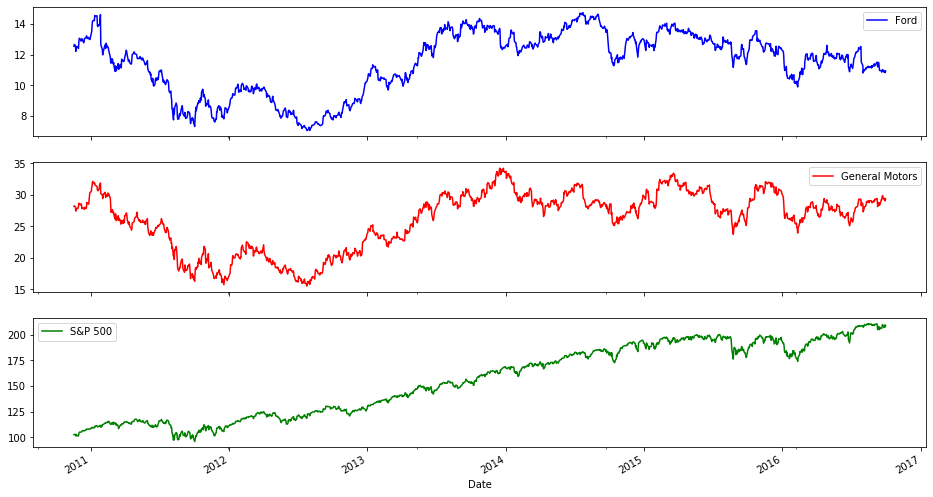

```python
cointprices.plot(figsize=(16,9), color=('b', 'r', 'g'), subplots=True) #https://matplotlib.org/3.1.1/gallery/color/named_colors.html
```

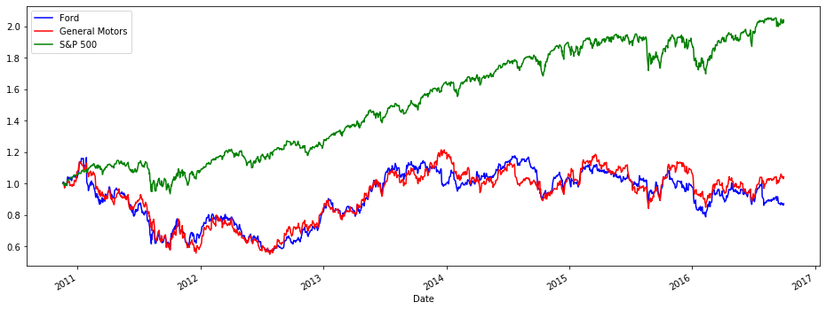

```python
cointprices_1 = cointprices/cointprices.iloc[0]
cointprices_1.plot(figsize=(16,6), color=('b', 'r', 'g'))
```

Cointegration testing is sensitive to **the initial value**

Normalising to start at one -- also allows 1:1 comparison of P&L:

- Both, Ford and General Motors delivered about 0% average annual return -- if we look at the performance over these five-year period.
- S&P 500 index, on the other hand, delived an average annual return > 12%

### Daily Returns

```
array([<matplotlib.axes._subplots.AxesSubplot object at 0x7fb32889bf50>,
      dtype=object)
```

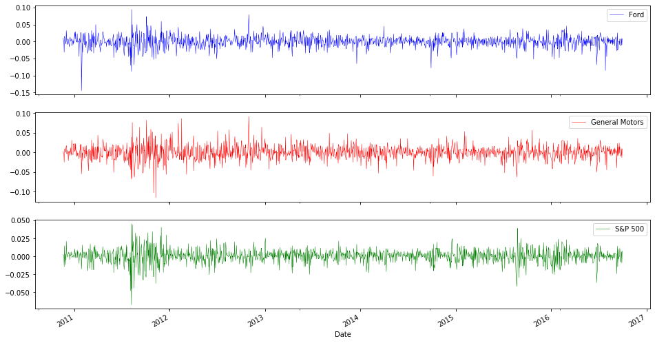

```python
returns = np.log(cointprices).diff().dropna()
returns.plot(figsize=(16,9), color=('b', 'r', 'g'), subplots=True, linewidth=0.5)
```

```python
VAR_Demo = CODE_MATRIX_FORM(returns, 1)
VAR_Demo.fit
```

|  | Estimate Ford | Estimate General Motors | Estimate S&P 500 | SD of Estimate Ford | SD of Estimate General Motors | SD of Estimate S&P 500 | t-Statistic Ford | t-Statistic General Motors | t-Statistic S&P 500 |
| --- | --- | --- | --- | --- | --- | --- | --- | --- | --- |
| Constant | -0.000049 | 0.000031 | 0.000508 | 0.000448 | 0.000481 | 0.000250 | -0.108667 | 0.065476 | 2.037382 |
| (Lag 1, Ford) | 0.102431 | 0.059577 | 0.004979 | 0.041445 | 0.044499 | 0.023086 | 2.471511 | 1.338832 | 0.215685 |
| (Lag 1, General Motors) | -0.005268 | -0.018783 | 0.004345 | 0.036682 | 0.039385 | 0.020433 | -0.143620 | -0.476908 | 0.212667 |
| (Lag 1, S&P 500) | -0.087447 | 0.000511 | -0.056109 | 0.068361 | 0.073398 | 0.038079 | -1.279192 | 0.006964 | -1.473508 |

To investigate whether the daily returns depend on their past values, we fit the VAR(1) model to DAILY RETURNS (above, to be read **column-wise**)

The question now is whether the estimated coefficients are significantly different from zero. We inspect the $p$-values. We will reject the hypothesis that a regression coefficient is zero if the corresponding $p$-value is less than 5%.

In the table below TRUE indicates a regression coefficient that is SIGINIFICANTLY DIFFERENT from zero:

```python
VAR_Demo.pvalue<0.05
```

|  | Ford | General Motors | S&P 500 |
| --- | --- | --- | --- |
| Constant | False | False | True |
| (Lag 1, Ford) | True | False | False |
| (Lag 1, General Motors) | False | False | False |
| (Lag 1, S&P 500) | False | False | False |

The outcome is not very promising.

To investigate and re-check if we should have included more past values in the model, we check Information Criteria (AIC, BIC) for the range $p=1, \ldots, 10$:

```python
IC = pd.DataFrame([CODE_MATRIX_FORM(returns, p+1).IC for p in range(10)], index=[p+1 for p in range(10)])
IC
```

|  | AIC | BIC |
| --- | --- | --- |
| 1 | -26.908843 | -26.865753 |
| 2 | -26.899725 | -26.824277 |
| 3 | -26.902051 | -26.794209 |
| 4 | -26.897263 | -26.756991 |
| 5 | -26.904856 | -26.732119 |
| 6 | -26.893282 | -26.688043 |
| 7 | -26.884298 | -26.646522 |
| 8 | -26.876298 | -26.605948 |
| 9 | -26.872130 | -26.569171 |
| 10 | -26.860620 | -26.525015 |

We select by the largest modulus (absolute value), in this case, optimal lag $p=1$ according to the both, AIC and BIC.

```python
IC.idxmin()
```

```
AIC    1
BIC    1
dtype: int64
```

The above vignette analysis of returns can be concluded that past lagged values cannot be used to predict the future returns for these two equties.

Things can be different for market indicies and for over long-term, 15-30 years of daily data or even more, but that has limited applicability.

# Cointegration Analysis

In this section we implement the Engle-Granger procedure to confirm (or not) if the pair is cointegrated and therefore, suitable for trade design.

We begin by recapping what the prices for Ford and General Motors from before look like:

## Engle-Granger Procedure

```
array([<matplotlib.axes._subplots.AxesSubplot object at 0x7fb33bb6ced0>,
      dtype=object)
```

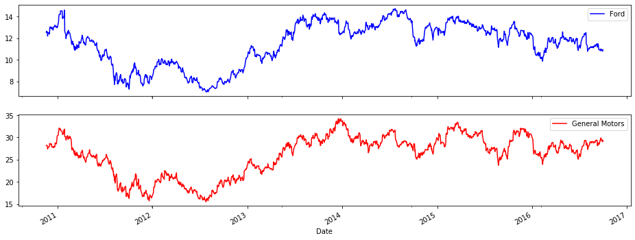

```python
Price_B = cointprices.iloc[:, [1]] #GM stock price -- variable X
Price_A = cointprices.iloc[:, [0]] #Ford stock price -- variable Y

cointprices.iloc[:, [0,1]].plot(figsize=(16,6), color=('b', 'r'), subplots=True)
```

- Improvement 0. Appropriate to remind that we **HAVE NOT NORMALISED** F and GM time series by the initial value -- to begin at 1 each.

### ENGLE-GRANGER STEP 1. Cointegrated Residual (spread e_t)

We are now ready to perform the 1st step of the Engle-Granger procedure which is to estimate the model:

\begin{equation} \text{Ford}_t = \beta \, \text{GM}_t + \mu_e + \varepsilon_t \end{equation}

and so, our **NAIVE** cointegrated residual is

\begin{equation} e_t = Ford_t - 0.4066 \, GM_t - 0.8682 \end{equation}

Vector cointegrating weights can be fine-tuned by running the ready multivariate cointegration (VECM routines, such as *cajorls* in R package *urca* )

\begin{equation} \boldsymbol\beta_{Coint} = [1, -0.4066] \qquad \qquad \mu_e = -0.8682 \end{equation}

```python
EG_1 = linear_regression(Price_A, Price_B, 'c')
EG_1.fit
```

|  | Estimate Ford | SD of Estimate Ford | t-Statistic Ford |
| --- | --- | --- | --- |
| Constant | 0.868166 | 0.106511 | 8.150924 |
| General Motors | 0.406757 | 0.004021 | 101.159333 |

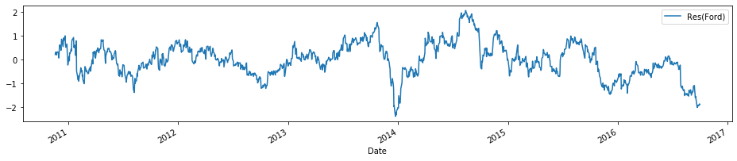

```python
e = EG_1.residuals
e.plot(figsize=(16,3))
```

The question now is whether the residual series is stationary -- has no unit root (randomness). We perform Augmented Dickey-Fuller Test on this Cointegrated residual (therefore, referred to as CADF).

**NAIVE COINTEGRATING RELATIONSHIP** Though the stationarity of residual is important, here it only transpires over > 4-year period. Regressing one equity price on another arbitrarily does not create cointegration. This is a first step in the analysis of a potential long-run relationship between the two time series $P^A_t$ and $P^B_t$.

```python
CODE_ADF(e).fit
```

```
Number of lags used: 1
```

|  | Estimate ΔRes(Ford) | SD of Estimate ΔRes(Ford) | t-Statistic ΔRes(Ford) |
| --- | --- | --- | --- |
| Constant | 0.005364 | 0.007632 | 0.702889 |
| Trend | -0.000009 | 0.000009 | -1.030575 |
| (Lag 1, Res(Ford)) | -0.019780 | 0.005417 | -3.651647 |
| (Lag 1, ΔRes(Ford)) | 0.024925 | 0.018565 | 1.342579 |

#### ADF TEST EQUATION

\begin{equation*} \Delta e_t = \varphi e_{t-1} + \varphi_{aug1} \Delta e_{t-1} + const + \varphi_t t + \varepsilon_t \end{equation*}

Look at the value of test statistic for the parameter $\varphi$. In this case, it is -3.65 which is lower than the 5% Dickey-Fuller critical value of -3.45 (but not much lower). We reject the $H_0$ hypothesis of unit root (see Cointegration Lecture). The residuals are stationary.

- Improvement 1. Test equation above includes time dependence $\varphi_t t$, referred to as 'trend'.

**DO NOT INCLUDE** trend in your ADF tests and cointegrating residual -- it will make you think cointegration is present when it is very weak. In fact, without $\varphi_t t$ term, we might not even get stationarity result.

### ENGLE-GRANGER STEP 2. Error correction equations

In general form,

\begin{equation*} \Delta P^A_t = \varphi \Delta P^B_t - (1-\alpha) \widehat{e}_{t-1} + \varepsilon_t \end{equation*}

We are now in position to perform **the 2nd step of Engle-Granger** procedure which is to estimate the Equilibrium Correction Model, or error correction equations:

\begin{equation*} \Delta \text{Ford_Price}_t = \varphi \Delta\text{GM_Price}_t - (1-\alpha) \text{Coint_FordGM}_{t-1} + \varepsilon_t \end{equation*}

```python
#Price_B = cointprices.iloc[:, [1]] #GM stock price -- variable X
#Price_A = cointprices.iloc[:, [0]] #Ford stock price -- variable Y

ΔPrice_A = pd.DataFrame(Price_A).diff().dropna().add_prefix('Δ')

ΔPrice_B = pd.DataFrame(Price_B).diff().dropna().add_prefix('Δ')
rhs = ΔPrice_B.join(e.shift(1).dropna().add_prefix('(Lag 1, ').add_suffix(')'))
#where e = EG_1.residuals
```

```python
EG_2 = linear_regression(ΔPrice_A, rhs, '')
EG_2.fit
```

|  | Estimate ΔFord | SD of Estimate ΔFord | t-Statistic ΔFord |
| --- | --- | --- | --- |
| ΔGeneral Motors | 0.294164 | 0.007947 | 37.017757 |
| (Lag 1, Res(Ford)) | -0.014555 | 0.005032 | -2.892389 |

Here we check significance of $-(1-\alpha)$ term -- that ensures the correction the long run equilibrium.

In error correction equation the $p$-value is evaluated agaist t-distribution as is common for regression. We will reject $H_0$ that a regression coefficient is zero if the corresponding $p$-value is less than 5%. In the table below "True" indicates a regression coefficient that is siginificantly different from zero:

```python
EG_2.pvalue<0.05
```

|  | ΔFord |
| --- | --- |
| ΔGeneral Motors | True |
| (Lag 1, Res(Ford)) | True |

### EG Correction Equation "other way around" (GM on Ford)

To fully complete checks, we should estimate **EG STEP 1** the other way around: General Motors on Ford.

\begin{equation*} \Delta \text{GM_Price}_t = \varphi \Delta\text{Ford_Price}_t - (1-\alpha) \text{Coint_FordGM}_{t-1} + \varepsilon_t \end{equation*}

```python
rhs_ow = ΔPrice_A.join(e.shift(1).dropna().add_prefix('(Lag 1, ').add_suffix(')')) # pluggin in 'wrong way' residuals
EG_2_ow = linear_regression(ΔPrice_B, rhs_ow, '')
EG_2_ow.fit
```

|  | Estimate ΔGeneral Motors | SD of Estimate ΔGeneral Motors | t-Statistic ΔGeneral Motors |
| --- | --- | --- | --- |
| ΔFord | 1.637771 | 0.044243 | 37.017757 |
| (Lag 1, Res(Ford)) | 0.044028 | 0.011852 | 3.714754 |

### Correcting the correction

- Improvement 3. The residual also needs to be re-stimated for GM on Ford, and preferrably also tested by Augmended Dickey-Fuller test before proceeding.

\begin{equation*} \Delta \text{GM_Price}_t = \varphi \Delta\text{Ford_Price}_t - (1-\alpha) \text{Coint_GMFord}_{t-1} + \varepsilon_t \end{equation*}

The proper cointegrated residual to use now is

\begin{equation} e_t = GM_t - 2.1488 \, Ford_t - 1.4213 \end{equation}

The second candidate to be a cointegrated relationship (weights) vector.

\begin{equation} \boldsymbol\beta_{Coint} = [1, - 2.1488] \qquad \qquad \mu_e = -1.4213 \end{equation}

```python
EG_1_ow = linear_regression(Price_B, Price_A, 'c') #linear_regression(x, y, 'c')
EG_1_ow.fit
```

|  | Estimate General Motors | SD of Estimate General Motors | t-Statistic General Motors |
| --- | --- | --- | --- |
| Constant | 1.421283 | 0.247507 | 5.742398 |
| Ford | 2.148750 | 0.021241 | 101.159333 |

```python
CODE_ADF(EG_1_ow.residuals).fit
```

```
Number of lags used: 1
```

|  | Estimate ΔRes(General Motors) | SD of Estimate ΔRes(General Motors) | t-Statistic ΔRes(General Motors) |
| --- | --- | --- | --- |
| Constant | -0.025940 | 0.018285 | -1.418671 |
| Trend | 0.000040 | 0.000022 | 1.817531 |
| (Lag 1, Res(General Motors)) | -0.022476 | 0.005709 | -3.936824 |
| (Lag 1, ΔRes(General Motors)) | 0.019613 | 0.018487 | 1.060908 |

ADF on the residual form that regression gives stronger test statistic $-3.94$ for the parameter $\varphi$. We should have estimated model that way from the start, eg GM on Ford.

```python
e_ow = EG_1_ow.residuals
```

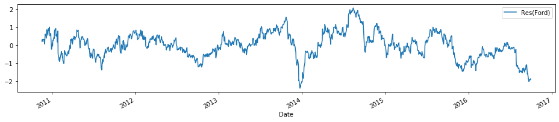

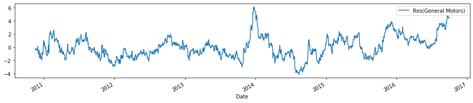

```python
e.plot(figsize=(16,3))
e_ow.plot(figsize=(16,3))
```

**We have estimated**

\begin{equation*} \Delta \text{Ford_Price}_t = \varphi \Delta\text{GM_Price}_t - (1-\alpha) \text{Coint_FordGM}_{t-1} + \varepsilon_t \end{equation*}

```python
EG_2 = linear_regression(ΔPrice_A, rhs, '')
EG_2.fit
```

|  | Estimate ΔFord | SD of Estimate ΔFord | t-Statistic ΔFord |
| --- | --- | --- | --- |
| ΔGeneral Motors | 0.294164 | 0.007947 | 37.017757 |
| (Lag 1, Res(Ford)) | -0.014555 | 0.005032 | -2.892389 |

\begin{equation*} \Delta \text{GM_Price}_t = \varphi \Delta\text{Ford_Price}_t - (1-\alpha) \text{Coint_GMFord}_{t-1} + \varepsilon_t \end{equation*}

```python
rhs_ow = ΔPrice_A.join(e_ow.shift(1).dropna().add_prefix('(Lag 1, ').add_suffix(')'))
EG_2_ow = linear_regression(ΔPrice_B, rhs_ow, '')
EG_2_ow.fit
```

|  | Estimate ΔGeneral Motors | SD of Estimate ΔGeneral Motors | t-Statistic ΔGeneral Motors |
| --- | --- | --- | --- |
| ΔFord | 1.634879 | 0.044235 | 36.958582 |
| (Lag 1, Res(General Motors)) | -0.019399 | 0.005157 | -3.761997 |

### QUALITY OF REVERSION -- "STEP 3" to ENGLE-GRANGER PROCEDURE

The strategy trades the spread from the long/short portfolio -- weights given $\boldsymbol\beta_{Coint}$. Profitability and trade-offs (frequency of trades vs. profit per trade) will become clearer from after we fit the cointegrated residual, spread $e_t$, to the Ornstein-Uhlenbeck process.

\begin{equation*} \text{d} e_{t+\tau} = -\theta(e_{t}-\mu) \,\text{dt}+\sigma_{OU} \text{dW}_t \end{equation*}

AR(1) on the spread itself is guaranteed -- see *Learning and Trusting Cointegration in Statistical Arbitrage* by Richard Diamond, **WILMOTT Magazine**, November 2013, Issue 68. [SSRN link](https://papers.ssrn.com/sol3/papers.cfm?abstract_id=2220092)

\begin{equation*} \widehat{e}_t = C + B \widehat{e}_{t-1} + \varepsilon_t \end{equation*}

```python
OU = VAR(e, 1)
OU.fit
```

|  | Estimate Res(Ford) | SD of Estimate Res(Ford) | t-Statistic Res(Ford) |
| --- | --- | --- | --- |
| Constant | -0.001390 | 0.003782 | -0.367687 |
| (Lag 1, Res(Ford)) | 0.981062 | 0.005354 | 183.251409 |

Since we are analysing daily data we have...

```python
tau = 1/252
```

and so

```python
theta = -np.log(OU.fit.iloc[1, 0])/tau
theta
```

```
4.818244729386412
```

This indicates a half-life of...

```python
H = np.log(2)/theta
H
```

```
0.14385885721670585
```

**year fraction** -- for 1 month of time, $\tau=0.0833$ (year fraction).

H corresponds to the following number of *working days*:

```python
H/tau
```

```
36.25243201860988
```

36 working days.

The speed of mean-reversion, in this case, is not particularly fast so we might not expect that many trades when implementing the strategy that trades the spread by constructing a long/short portfolio.

As mentioned earlier we could also have done the regression in step 1 the other way around, and we saw that the resulting residuals were also stationary. Had we done the entire Engle-Granger procedure the other way around, the resulting half-life would have been 28.4 days. Since this is similar to the above, we will stick with 'Ford' as being our lead variable.

```python
# DEMO STOPS
# DELEGATES TO IMPLEMENT SIGMA_EQ COMPUTATION AND VALIDATION, Z*, and PAIR TRADE P&L
```